# pre_lab_10.Rmd

Derek Willis

2024-08-06

## Chapter 23

Up to now, we’ve been looking at patterns in data for what is more than this, or what’s the middle look like. We’ve calculated metrics like per capita rates, or looked at how data changes over time.

Another way we can look at the data is geographically. Is there a spatial pattern to our data? Can we learn anything by using distance as a metric? What if we merge non-geographic data into geographic data?

The bad news is that there isn’t a One Library To Rule Them All when it comes to geo queries in R. But there’s one emerging, called Simple Features, that is very good.

Go to the console and install it with `install.packages("sf")`

To understand geographic queries, you have to get a few things in your head first:

1. Your query is using planar space. Usually that’s some kind of projection of the world. If you’re lucky, your data is projected, and the software will handle projection differences under the hood without you knowing anything about it.
2. Projections are cartographers making opinionated decisions about what the world should look like when you take a spheroid – the earth isn’t perfectly round – and flatten it. Believe it or not, every state in the US has their own geographic projection. There’s dozens upon dozens of them.
3. Geographic queries work in layers. In most geographic applications, you’ll have multiple layers. You’ll have a boundary file, and a river file, and a road file, and a flood file and combined together they make the map. But you have to think in layers.
4. See 1. With layers, they’re all joined together by the planar space. So you don’t need to join one to the other like we did earlier – the space has done that. So you can query how many X are within the boundaries on layer Y. And it’s the plane that holds them together.

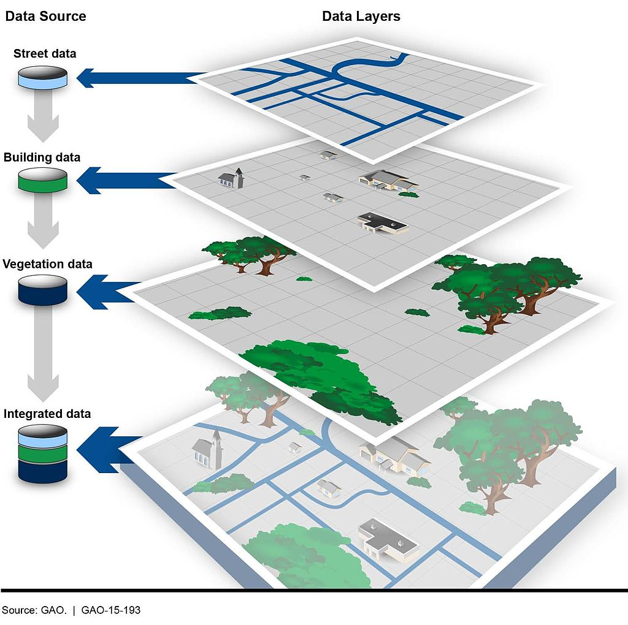

## Importing and viewing data

Let’s start with the absolute basics of geographic data: loading and viewing. Load libraries as usual.

### Task 1: Load packages

**Task** Run the following code to load packages.

```r
library(tidyverse)
library(sf)
library(janitor)
```

First: an aside on geographic data. There are many formats for geographic data, but data type you’ll see the most is called the shapefile. It comes from a company named ERSI, which created the most widely used GIS software in the world. For years, they were the only game in town, really, and the shapefile became ubiquitous, especially so in government and utilities.

So more often than not, you’ll be dealing with a shapefile. But a shapefile isn’t just a single file – it’s a collection of files that combined make up all the data that allow you to use it. There’s a .shp file – that’s the main file that pulls it all together – but it’s important to note if your shapefiles has a .prj file, which indicates that the projection is specified.

You also might be working with a GeoDatabase, or a .gdb file. That’s a slightly different, more compact version of a Shapefile.

The data we’re going to be working with is a GeoDatabase from the [Prince George’s County Department of Planning](https://gisdata.pgplanning.org/opendata/) that contains information about the county’s election precincts.

### Task: Load the Prince George’s County election precinct data.

Simlar to `readr`, the `sf` library has functions to read geographic data. In this case, we’re going to use `st_read` to read in our precinct data. And then glimpse it to look at the columns.

### Task: Load data

**Task** Run the following code to load data. Describe what you see in the answer space below. What columns exist in this data?

**Answer** The columns that exist in this dataset are precinct names and ID’s, congress, legis, councils, school, polling id’s, and then shapes with their lengths and areas. This all represents county election data with its geographic locations in PG County.

```r
pg_precincts <- st_read("data/Election_Precinct_2022_Py.gdb")
glimpse(pg_precincts)
```

```
## Rows: 356
## Columns: 10
## $ PRECINCT_ID   <chr> "003-004", "010-009", "012-002", "013-023", "013-006", "…
## $ PRECINCT_NAME <chr> "PERRYWOOD ELEMENTARY SCHOOL", "OAKLANDS ELEMENTARY SCHO…
## $ CONGRESS      <chr> "5", "4", "4", "5", "5", "5", "5", "4", "4", "5", "5", "…
## $ LEGIS         <chr> "25", "21", "26", "24", "25", "23", "25", "25", "26", "2…
## $ COUNCIL       <chr> "6", "1", "8", "6", "6", "9", "9", "9", "8", "9", "6", "…
## $ SCHOOL        <chr> "7", "1", "8", "6", "6", "9", "9", "9", "8", "9", "6", "…
## $ POLLING_ID    <chr> "003-004", "010-009", "012-002", "013-023", "013-006", "…
## $ Shape_Length  <dbl> 57210.064, 32694.336, 18569.900, 9904.106, 26469.667, 32…
## $ Shape_Area    <dbl> 120064600, 41053127, 16555067, 6072400, 33437592, 347735…
## $ Shape         <GEOMETRY [US_survey_foot]> MULTIPOLYGON (((1378044 433..., MU…
```

This looks like a normal dataframe, and mostly it is. We have one row per precinct, and each column is some feature of that precinct: the ID, name and more. What sets this data apart from other dataframes we’ve used is the last column, “Shape”, which is of a new data type. It’s not a character or a number, it’s a “Multipolygon”, which is composed of multiple longitude and latitude values. When we plot these on a grid of latitude and longitude, it will draw those shapes on a map.

Let’s look at these precincts. We have 356 of them, according to this data.

### Task: Run code

**Task** Run the following code. Describe the output in the space below: what kind of information does it contain?

```r
View(pg_precincts)
```

But where in Prince George’s County are these places? We can simply plot them on a longitude-latitude grid using ggplot and geom_sf.

### Task: Run code

**Task** Run the following code. Describe the output in the space below. **Answer**

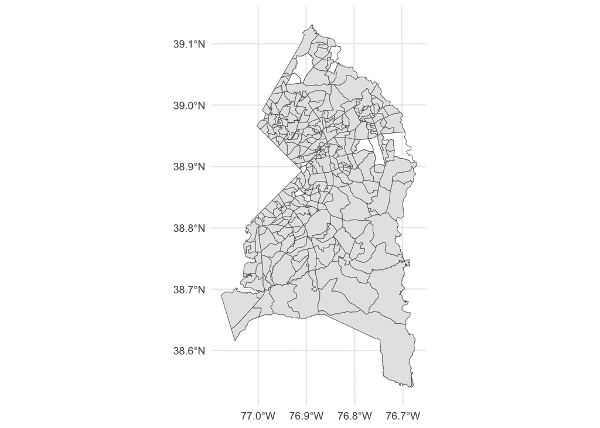

```r
pg_precincts |>
  ggplot() +
  geom_sf() +
  theme_minimal()
```

Each shape is a precinct, with the boundaries plotted according to its degrees of longitude and latitude.

If you know anything about Prince George’s, you can kinda pick out the geographic context here. To the west is the District of Columbia, for example. College Park is near the top. But this map is not exactly ideal. It would help to have a state and county map layered underneath of it, to help make sense of the spatial nature of this data.

This is where layering becomes more clear. First, we want to go out and get another shapefile, this one showing Maryland county outlines.

Instead of loading it from our local machine, like we did above, we’re going to use a package to directly download it from the U.S. Census. The package is called `tigris` and it’s developed by the same person who made `tidycensus`.

In the console, install tigris with `install.packages('tigris')`

Then load it:

### Task: Run code

**Task** Run the following code. Describe the output in the space below. **Answer**

```r
# install.packages('tigris')
library(tigris)
```

Now, let’s use the counties() function from tigris to pull down a shapefile of all U.S. counties.

### Task: Run code

**Task** Run the following code. Describe the output in the space below. **Answer**

```r
counties <- counties()
```

[output not shown]

```r
glimpse(counties)
```

```
## Rows: 3,235
## Columns: 18
## $ STATEFP  <chr> "31", "53", "35", "31", "31", "72", "46", "48", "06", "21", "…
## $ COUNTYFP <chr> "039", "069", "011", "109", "129", "085", "099", "327", "091"…
## $ COUNTYNS <chr> "00835841", "01513275", "00933054", "00835876", "00835886", "…
## $ GEOID    <chr> "31039", "53069", "35011", "31109", "31129", "72085", "46099"…
## $ NAME     <chr> "Cuming", "Wahkiakum", "De Baca", "Lancaster", "Nuckolls", "L…
## $ NAMELSAD <chr> "Cuming County", "Wahkiakum County", "De Baca County", "Lanca…
## $ LSAD     <chr> "06", "06", "06", "06", "06", "13", "06", "06", "06", "06", "…
## $ CLASSFP  <chr> "H1", "H1", "H1", "H1", "H1", "H1", "H1", "H1", "H1", "H1", "…
## $ MTFCC    <chr> "G4020", "G4020", "G4020", "G4020", "G4020", "G4020", "G4020"…
## $ CSAFP    <chr> NA, NA, NA, NA, NA, NA, NA, NA, NA, NA, NA, NA, NA, NA, NA, N…
## $ CBSAFP   <chr> NA, NA, NA, NA, NA, NA, NA, NA, NA, NA, NA, NA, NA, NA, NA, N…
## $ METDIVFP <chr> NA, NA, NA, NA, NA, NA, NA, NA, NA, NA, NA, NA, NA, NA, NA, N…
## $ FUNCSTAT <chr> "A", "A", "A", "A", "A", "A", "A", "A", "A", "A", "A", "A", "…
## $ ALAND    <dbl> 1477644346, 680980770, 6016818946, 2169272978, 1489645185, 87…
## $ AWATER   <dbl> 10691216, 61564427, 29090018, 22847034, 1718484, 32509, 18182…
## $ INTPTLAT <chr> "+41.9158651", "+46.2946377", "+34.3592729", "+40.7835474", "…
## $ INTPTLON <chr> "-096.7885168", "-123.4244583", "-104.3686961", "-096.6886584…
## $ geometry <MULTIPOLYGON [°]> MULTIPOLYGON (((-96.55515 4..., MULTIPOLYGON (((…
```

This looks pretty similar to our places shapefile, in that it looked mostly like a normal dataframe with the exception of the new geometry column (this time called `geometry`, which is pretty common).

### Task: Run code

**Task** Run the following code. Describe the output in the space below. **Answer**

```r
md_counties <- counties |>
  filter(STATEFP == "24")
```

To see what this looks like, let’s plot it out with ggplot. We can pretty clearly see the shapes of Maryland counties.

### Task: Run code

**Task** Run the following code. Describe the output in the space below. **Answer**

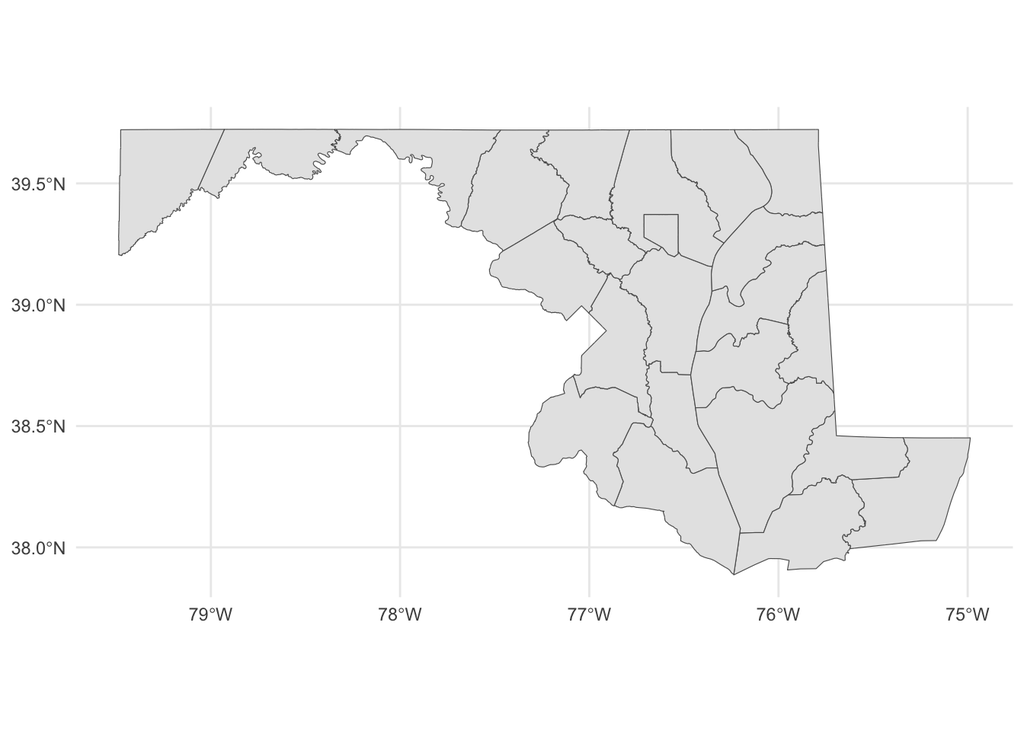

```r
md_counties |>
  ggplot() +
  geom_sf() +
  theme_minimal()
```

With this county map, we can layer our places data. We’ll narrow it down to just Prince George’s County to get an outline.

Something to note: The layers are rendered in the order they appear. So the first geom_sf is rendered first. The second geom_sf is rendered ON TOP OF the first one.

We’re also going to change things up a bit to put the datasets we want to display INSIDE of the geom_sf() function, instead of starting with a dataframe. We have two to plot now, so it’s easier this way.

### Task: Run code

**Task** Run the following code. Describe the output in the space below. **Answer**

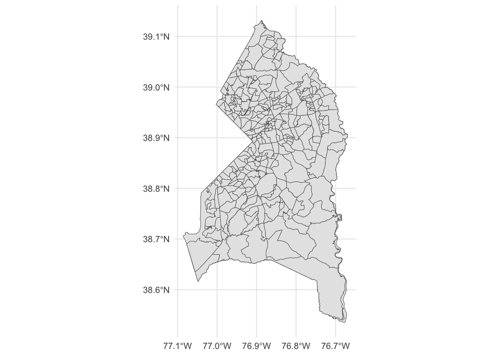

```r
ggplot() +
  geom_sf(data=md_counties |> filter(COUNTYFP == "033")) +
  geom_sf(data=pg_precincts) +
  theme_minimal()
```

Notice the subtle differences at the boundaries?

### Task: Run code to load the turnout data from the May 2024 Primary election

**Task** Run the following code. Describe the output in the space below. **Answer**

```r
primary_24 <- read_csv("data/Official by Party and Precinct.csv") |> clean_names()
pg_turnout <- primary_24 |>
  filter(lbe == "Prince George's") |>
  group_by(precinct) |>
  summarise(total_polls = sum(polls), total_early = sum(early_voing), total_absentee = sum(absentee), total_provisional = sum(provisional), total_eligible = sum(eligible_voters))

View(pg_turnout)
```

Now we can join the precincts to the turnout data.

### Task: Run code to join the precinct shapes with the voter turnout data

**Task** Run the following code. Describe the output in the space below. **Answer**

```r
pg_precincts_with_turnout <- pg_precincts |> left_join(pg_turnout, by=c("PRECINCT_ID"="precinct"))
```

Now we can use color to distinguish precincts from each other. Let’s use the total eligible voters to start with:

### Task: Run code

**Task** Run the following code. Describe the output in the space below. **Answer**

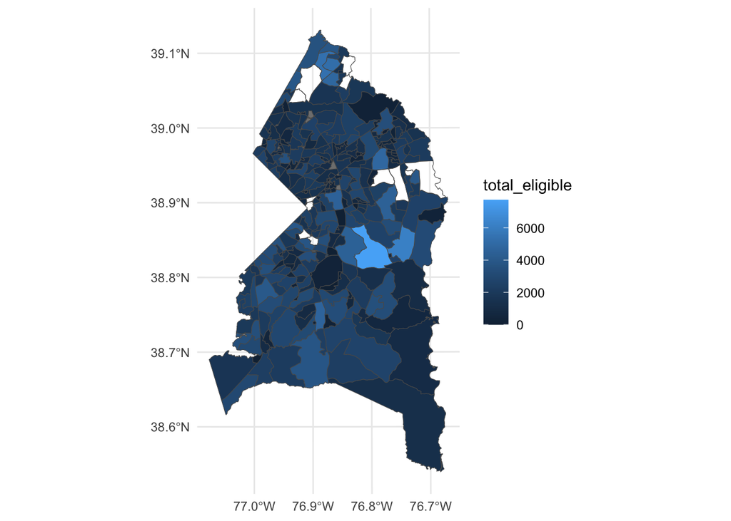

```r
ggplot() +
  geom_sf(data=pg_precincts_with_turnout, aes(fill=total_eligible)) +
  scale_colour_viridis_b(option="magma") +
  theme_minimal()
```

## Chapter 24

In the previous chapter, we looked at election precincts in Prince George’s County to show a bit of a pattern regarding concentration of the precincts with the most and 0 eligible voters. Let’s go little further and look at voters statewide.

First, let’s load the libraries we’ll need. We’re also going to load tidycensus and set an API key for tidycensus.

### Task: Load libraries

**Task** Run the following code.

```r
library(tidyverse)
library(sf)
library(janitor)
library(tidycensus)
```

For the rest of this chapter, we’re going to work on building a map that will help us gain insight into geographic patterns in voter registration by county in Maryland. Our question: by examining the number of Democrats/Republicans/Unaffiliated voters per 10,000 people in each county, what regional geographic patterns can we identify?

We’ve got voters by county, so let’s load that from the data folder and take a look:

### Task: Run code

**Task** Run the following code. Describe the output in the space below. **Answer**

```r
voters_by_county <- read_csv("data/eligible_voters.csv")
voters_by_county |> arrange(desc(TOTAL))
```

```
## # A tibble: 24 × 9
##    County              DEM    REP   LIB   OTH    UNA   NLM   GRN  TOTAL
##    <chr>             <dbl>  <dbl> <dbl> <dbl>  <dbl> <dbl> <dbl>  <dbl>
##  1 Montgomery       403843  98946  2481  6031 170306  1053   855 683515
##  2 Prince George's  455749  40327  1648 11549  99412  1068   637 610390
##  3 Baltimore County 306847 139293  2699  6892 118059   864   711 575365
##  4 Anne Arundel     172652 129077  2491  3678 103458   699   465 412520
##  5 Baltimore City   298865  29211  1254  5020  63722   698   736 399506
##  6 Howard           122630  48498   959  2148  61796   346   264 236641
##  7 Frederick         78431  68686  1252  1468  52988   274   232 203331
##  8 Harford           64081  80972  1281  2002  44122   276   164 192898
##  9 Carroll           33091  63932   853  1187  29928   122   137 129250
## 10 Charles           75333  23363   448  1092  24603   160   109 125108
## # ℹ 14 more rows
```

So, what do we see here? Montgomery County has the most, followed by Prince George’s & Baltimore County. Checks out.

Next, we’ll go out and get population data for each county from tidycensus. The variable for total population is B01001_001.

### Task: Run code

**Task** Run the following code. Describe the output in the space below. **Answer**

```r
md_county_population <- get_acs(geography = "county",
              variables = c(population = "B01001_001"),
              state = "MD")
md_county_population
```

```
## # A tibble: 24 × 5
##    GEOID NAME                          variable   estimate   moe
##    <chr> <chr>                         <chr>         <dbl> <dbl>
##  1 24001 Allegany County, Maryland     population    67762    NA
##  2 24003 Anne Arundel County, Maryland population   590936    NA
##  3 24005 Baltimore County, Maryland    population   849586    NA
##  4 24009 Calvert County, Maryland      population    93791    NA
##  5 24011 Caroline County, Maryland     population    33406    NA
##  6 24013 Carroll County, Maryland      population   174318    NA
##  7 24015 Cecil County, Maryland        population   104366    NA
##  8 24017 Charles County, Maryland      population   168710    NA
##  9 24019 Dorchester County, Maryland   population    32612    NA
## 10 24021 Frederick County, Maryland    population   280341    NA
## # ℹ 14 more rows
```

Ultimately, we’re going to join this county population table with our voters by county table, and then calculate a voters per 10,000 people statistic. But remember, we then want to visualize this data by drawing a county map that helps us pick out trends. Thinking ahead, we know we’ll need a county map shapefile. Fortunately, we can pull this geometry information right from tidycensus at the same time that we pull in the population data by adding “geometry = TRUE” to our get_acs function.

### Task: Run code

**Task** Run the following code. Describe the output in the space below. **Answer**

```r
md_county_population <- get_acs(geography = "county",
              variables = c(population = "B01001_001"),
              state = "MD",
              year = 2022,
              geometry = TRUE)
```

[output not shown]

```r
md_county_population
```

```
## Simple feature collection with 24 features and 5 fields
## Geometry type: MULTIPOLYGON
## Dimension:     XY
## Bounding box:  xmin: -79.48765 ymin: 37.91172 xmax: -75.04894 ymax: 39.72304
## Geodetic CRS:  NAD83
## First 10 features:
##    GEOID                             NAME   variable estimate moe
## 1  24005       Baltimore County, Maryland population   850737  NA
## 2  24047       Worcester County, Maryland population    52827  NA
## 3  24031      Montgomery County, Maryland population  1056910  NA
## 4  24037      St. Mary's County, Maryland population   113814  NA
## 5  24017         Charles County, Maryland population   167035  NA
## 6  24021       Frederick County, Maryland population   273829  NA
## 7  24043      Washington County, Maryland population   154645  NA
## 8  24027          Howard County, Maryland population   332011  NA
## 9  24033 Prince George's County, Maryland population   957189  NA
## 10 24015           Cecil County, Maryland population   103876  NA
##                          geometry
## 1  MULTIPOLYGON (((-76.3257 39...
## 2  MULTIPOLYGON (((-75.66061 3...
## 3  MULTIPOLYGON (((-77.52728 3...
## 4  MULTIPOLYGON (((-76.74729 3...
## 5  MULTIPOLYGON (((-77.2724 38...
## 6  MULTIPOLYGON (((-77.67716 3...
## 7  MULTIPOLYGON (((-78.36346 3...
## 8  MULTIPOLYGON (((-77.18711 3...
## 9  MULTIPOLYGON (((-77.07995 3...
## 10 MULTIPOLYGON (((-76.23326 3...
```

We now have a new column, geometry, that contains the “MULTIPOLYGON” data that will draw an outline of each county when we go to draw a map.

The next step will be to join our population data to our voter data on the county column.

But there’s a problem. The column in our population data that has county names is called “NAME”, and it has the full name of the county spelled out in title case – first word capitalized and has “County” and “Maryland” in it. The voter data just has the name of the county. For example, the population data has “Anne Arundel County, Maryland” and the voter data has “Anne Arundel”.

### Task: Run code

**Task** Run the following code. Describe the output in the space below. **Answer**

```r
md_county_population
```

```
## Simple feature collection with 24 features and 5 fields
## Geometry type: MULTIPOLYGON
## Dimension:     XY
## Bounding box:  xmin: -79.48765 ymin: 37.91172 xmax: -75.04894 ymax: 39.72304
## Geodetic CRS:  NAD83
## First 10 features:
##    GEOID                             NAME   variable estimate moe
## 1  24005       Baltimore County, Maryland population   850737  NA
## 2  24047       Worcester County, Maryland population    52827  NA
## 3  24031      Montgomery County, Maryland population  1056910  NA
## 4  24037      St. Mary's County, Maryland population   113814  NA
## 5  24017         Charles County, Maryland population   167035  NA
## 6  24021       Frederick County, Maryland population   273829  NA
## 7  24043      Washington County, Maryland population   154645  NA
## 8  24027          Howard County, Maryland population   332011  NA
## 9  24033 Prince George's County, Maryland population   957189  NA
## 10 24015           Cecil County, Maryland population   103876  NA
##                          geometry
## 1  MULTIPOLYGON (((-76.3257 39...
## 2  MULTIPOLYGON (((-75.66061 3...
## 3  MULTIPOLYGON (((-77.52728 3...
## 4  MULTIPOLYGON (((-76.74729 3...
## 5  MULTIPOLYGON (((-77.2724 38...
## 6  MULTIPOLYGON (((-77.67716 3...
## 7  MULTIPOLYGON (((-78.36346 3...
## 8  MULTIPOLYGON (((-77.18711 3...
## 9  MULTIPOLYGON (((-77.07995 3...
## 10 MULTIPOLYGON (((-76.23326 3...
```

```r
voters_by_county
```

```
## # A tibble: 24 × 9
##    County              DEM    REP   LIB   OTH    UNA   NLM   GRN  TOTAL
##    <chr>             <dbl>  <dbl> <dbl> <dbl>  <dbl> <dbl> <dbl>  <dbl>
##  1 Allegany          10812  23016   274   495   8730    63    56  43446
##  2 Anne Arundel     172652 129077  2491  3678 103458   699   465 412520
##  3 Baltimore City   298865  29211  1254  5020  63722   698   736 399506
##  4 Baltimore County 306847 139293  2699  6892 118059   864   711 575365
##  5 Calvert           23494  28397   452   630  16229    95    64  69361
##  6 Caroline           5936  10830   124   222   4791    31    26  21960
##  7 Carroll           33091  63932   853  1187  29928   122   137 129250
##  8 Cecil             19013  34984   481   810  16965   126    72  72451
##  9 Charles           75333  23363   448  1092  24603   160   109 125108
## 10 Dorchester         9551   9456   110   252   4257    30    16  23672
## # ℹ 14 more rows
```

If they’re going to join properly, we need to clean one of them up to make it match the other.

Let’s clean the population table. We’re going to rename the “NAME” column to “County”, then remove “, Maryland” and “County” and make the county titlecase. Next we’ll remove any white spaces after that first cleaning step that, if left in, would prevent a proper join. We’re also going to rename the column that contains the population information from “estimate” to “population” and select only the county name and the population columns, along with the geometry. That leaves us with this tidy table.

### Task: Run code

**Task** Run the following code. Describe the output in the space below. **Answer**

```r
md_county_population <- md_county_population |>
  rename(County = NAME) |>
  mutate(County = str_to_title(str_remove_all(County,", Maryland|County"))) |>
  mutate(County = str_trim(County,side="both")) |>
  rename(population = estimate) |>
  select(County, population, geometry)

md_county_population
```

```
## Simple feature collection with 24 features and 2 fields
## Geometry type: MULTIPOLYGON
## Dimension:     XY
## Bounding box:  xmin: -79.48765 ymin: 37.91172 xmax: -75.04894 ymax: 39.72304
## Geodetic CRS:  NAD83
## First 10 features:
##             County population                       geometry
## 1        Baltimore     850737 MULTIPOLYGON (((-76.3257 39...
## 2        Worcester      52827 MULTIPOLYGON (((-75.66061 3...
## 3       Montgomery    1056910 MULTIPOLYGON (((-77.52728 3...
## 4       St. Mary's     113814 MULTIPOLYGON (((-76.74729 3...
## 5          Charles     167035 MULTIPOLYGON (((-77.2724 38...
## 6        Frederick     273829 MULTIPOLYGON (((-77.67716 3...
## 7       Washington     154645 MULTIPOLYGON (((-78.36346 3...
## 8           Howard     332011 MULTIPOLYGON (((-77.18711 3...
## 9  Prince George's     957189 MULTIPOLYGON (((-77.07995 3...
## 10           Cecil     103876 MULTIPOLYGON (((-76.23326 3...
```

Now we can join them.

### Task: Run code

**Task** Run the following code. Describe the output in the space below. **Answer**

```r
md_voters_per_10k <- md_county_population |>
  left_join(voters_by_county)
md_voters_per_10k
```

```
## Simple feature collection with 24 features and 10 fields
## Geometry type: MULTIPOLYGON
## Dimension:     XY
## Bounding box:  xmin: -79.48765 ymin: 37.91172 xmax: -75.04894 ymax: 39.72304
## Geodetic CRS:  NAD83
## First 10 features:
##             County population    DEM   REP  LIB   OTH    UNA  NLM GRN  TOTAL
## 1        Baltimore     850737     NA    NA   NA    NA     NA   NA  NA     NA
## 2        Worcester      52827  13586 19748  246   499   9070   56  42  43247
## 3       Montgomery    1056910 403843 98946 2481  6031 170306 1053 855 683515
## 4       St. Mary's     113814     NA    NA   NA    NA     NA   NA  NA     NA
## 5          Charles     167035  75333 23363  448  1092  24603  160 109 125108
## 6        Frederick     273829  78431 68686 1252  1468  52988  274 232 203331
## 7       Washington     154645  30537 44553  662   985  23635  149 127 100648
## 8           Howard     332011 122630 48498  959  2148  61796  346 264 236641
## 9  Prince George's     957189 455749 40327 1648 11549  99412 1068 637 610390
## 10           Cecil     103876  19013 34984  481   810  16965  126  72  72451
##                          geometry
## 1  MULTIPOLYGON (((-76.3257 39...
## 2  MULTIPOLYGON (((-75.66061 3...
## 3  MULTIPOLYGON (((-77.52728 3...
## 4  MULTIPOLYGON (((-76.74729 3...
## 5  MULTIPOLYGON (((-77.2724 38...
## 6  MULTIPOLYGON (((-77.67716 3...
## 7  MULTIPOLYGON (((-78.36346 3...
## 8  MULTIPOLYGON (((-77.18711 3...
## 9  MULTIPOLYGON (((-77.07995 3...
## 10 MULTIPOLYGON (((-76.23326 3...
```

Hang on - there’s at least one county with NA values - St. Mary’s, which is spelled “Saint Mary’s” in the voter dataframe. And Baltimore County didn’t match, either. Let’s fix that using if_else, which allows us to conditionally mutate:

### Task: Run code

**Task** Run the following code. Describe the output in the space below. **Answer**

```r
md_county_population <- md_county_population |>
  mutate(County = if_else(County == "St. Mary's", "Saint Mary's", County)) |>
  mutate(County = if_else(County == "Baltimore", "Baltimore County", County))
```

Our final step before visualization, let’s calculate the number of voters per 10,000 population for each county and sort from highest to lowest to see what trends we can identify just from the table.

### Task: Run code

**Task** Run the following code. Describe the output in the space below. **Answer**

```r
md_voters_per_10k <- md_county_population |>
  left_join(voters_by_county) |>
  mutate(voters_per_10k = TOTAL/population*10000) |>
  arrange(desc(voters_per_10k))
md_voters_per_10k
```

```
## Simple feature collection with 24 features and 11 fields
## Geometry type: MULTIPOLYGON
## Dimension:     XY
## Bounding box:  xmin: -79.48765 ymin: 37.91172 xmax: -75.04894 ymax: 39.72304
## Geodetic CRS:  NAD83
## First 10 features:
##          County population   DEM   REP  LIB  OTH   UNA NLM GRN  TOTAL
## 1     Worcester      52827 13586 19748  246  499  9070  56  42  43247
## 2  Queen Anne's      50316 11165 20302  237  328  8753  48  43  40876
## 3        Talbot      37663 10534 11597  174  242  5905  32  24  28508
## 4       Charles     167035 75333 23363  448 1092 24603 160 109 125108
## 5       Carroll     173225 33091 63932  853 1187 29928 122 137 129250
## 6       Calvert      93244 23494 28397  452  630 16229  95  64  69361
## 7     Frederick     273829 78431 68686 1252 1468 52988 274 232 203331
## 8       Harford     261059 64081 80972 1281 2002 44122 276 164 192898
## 9          Kent      19289  5719  5411   71  126  2764  21  14  14126
## 10   Dorchester      32557  9551  9456  110  252  4257  30  16  23672
##    voters_per_10k                       geometry
## 1        8186.533 MULTIPOLYGON (((-75.66061 3...
## 2        8123.857 MULTIPOLYGON (((-76.24918 3...
## 3        7569.232 MULTIPOLYGON (((-76.34647 3...
## 4        7489.927 MULTIPOLYGON (((-77.2724 38...
## 5        7461.394 MULTIPOLYGON (((-77.31116 3...
## 6        7438.656 MULTIPOLYGON (((-76.70121 3...
## 7        7425.474 MULTIPOLYGON (((-77.67716 3...
## 8        7389.058 MULTIPOLYGON (((-76.0921 39...
## 9        7323.345 MULTIPOLYGON (((-76.27737 3...
## 10       7270.940 MULTIPOLYGON (((-76.06544 3...
```

Okay, now let’s visualize. We’re going to build a choropleth map, with the color of each county – the fill – set according to the number of voters per 10K on a color gradient.

### Task: Run code

**Task** Run the following code. Describe the output in the space below. **Answer**

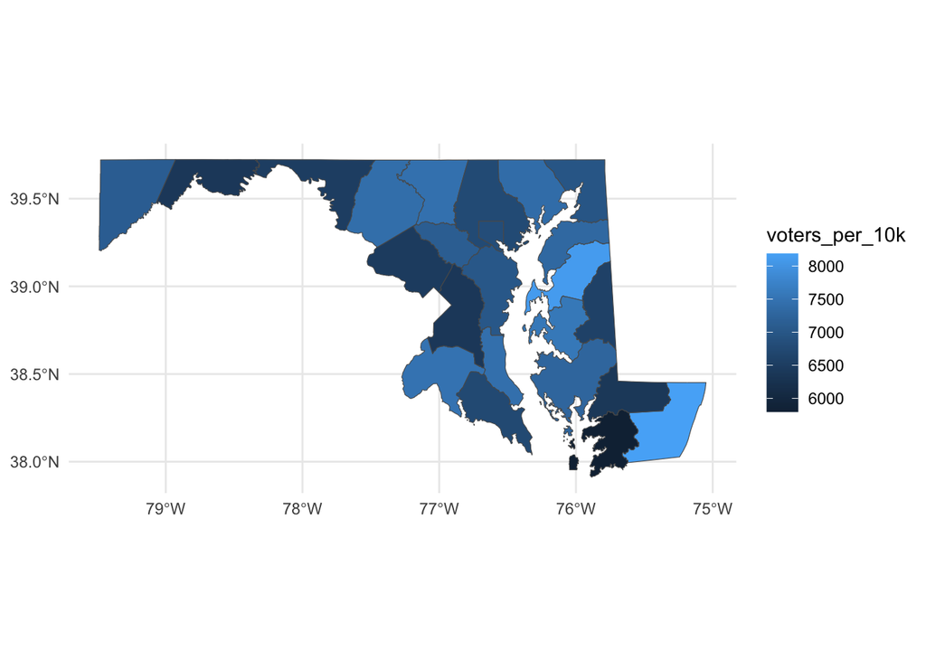

```r
ggplot() +
  geom_sf(data=md_voters_per_10k, aes(fill=voters_per_10k)) +
  theme_minimal()
```

This map is okay, but the color scale makes it hard to draw fine-grained differences. Let’s try applying the magma color scale we learned in the last chapter.

### Task: Run code

**Task** Run the following code. Describe the output in the space below. **Answer**

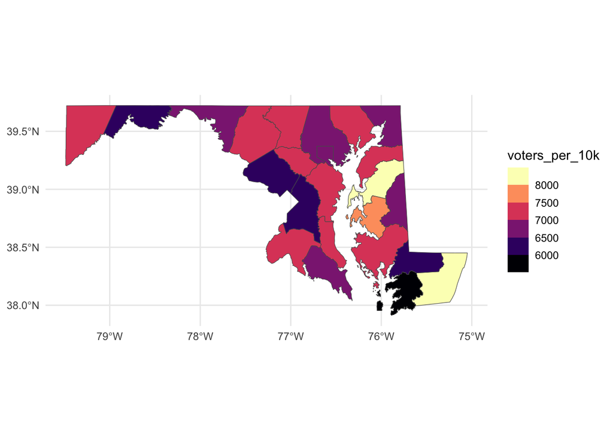

```r
ggplot() +
  geom_sf(data=md_voters_per_10k, aes(fill=voters_per_10k)) +
  theme_minimal() +
  scale_fill_viridis_b(option="magma")
```

The highest ranking counties stand out nicely in this version, but it’s still hard to make out fine-grained differences between other counties.

### Task: Run code

**Task** Run the following code. Describe the output in the space below. What regional patterns do you see? **Answer**

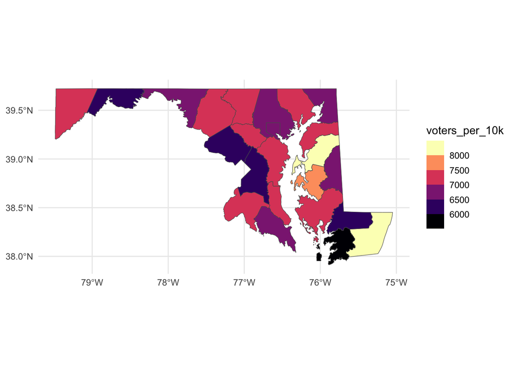

```r
ggplot() +
  geom_sf(data=md_voters_per_10k, aes(fill=voters_per_10k)) +
  theme_minimal() +
  scale_fill_viridis_b(option="magma",trans = "log")
```

Let’s repeat that for Unaffiliated voters:

### Task: Run code

**Task** Run the following code. Describe the output in the space below. **Answer**

```r
md_voters_per_10k <- md_voters_per_10k |>
  mutate(una_voters_per_10k = UNA/population*10000)
```

And then map it:

### Task: Run code

**Task** Run the following code. Describe the output in the space below. What regional patterns do you see, especially on the ends of the scale? **Answer**

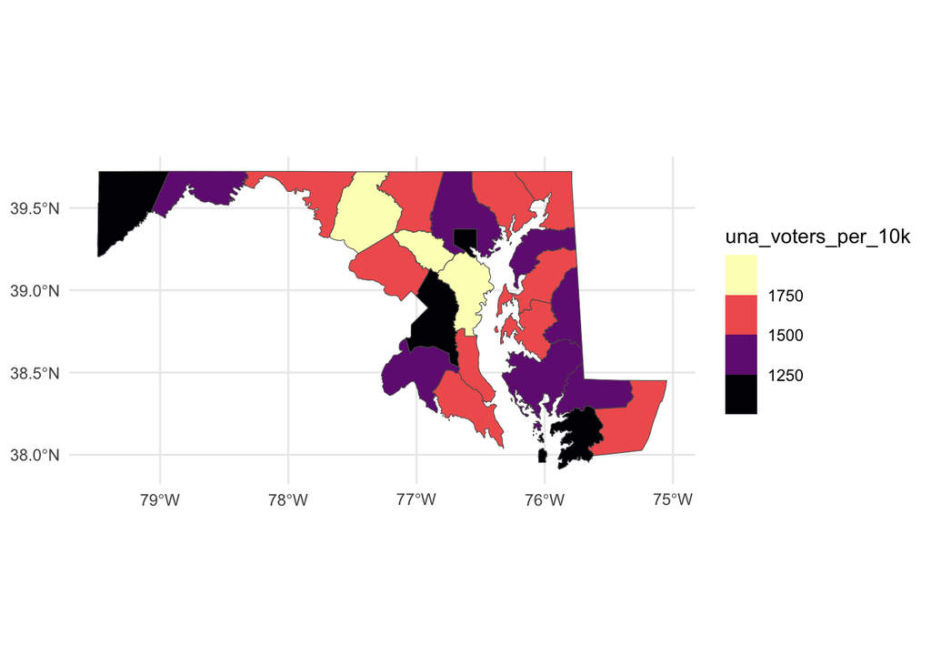

```r
ggplot() +
  geom_sf(data=md_voters_per_10k, aes(fill=una_voters_per_10k)) +
  theme_minimal() +
  scale_fill_viridis_b(option="magma",trans = "log")
```